# EasyVisa_Full_Code_Notebook

## Hyperparameter Tuning

**Best practices for hyperparameter tuning in AdaBoost:**

`n_estimators`:

- Start with a specific number (50 is used in general) and increase in steps: 50, 75, 85, 100
- Use fewer estimators (e.g., 50 to 100) if using complex base learners (like deeper decision trees)
- Use more estimators (e.g., 100 to 150) when learning rate is low (e.g., 0.1 or lower)
- Avoid very high values unless performance keeps improving on validation

`learning_rate`:

- Common values to try: 1.0, 0.5, 0.1, 0.01
- Use 1.0 for faster training, suitable for fewer estimators
- Use 0.1 or 0.01 when using more estimators to improve generalization
- Avoid very small values (< 0.01) unless you plan to use many estimators (e.g., >500) and have sufficient data

```python
%%time

#Defining trhe model.
model = AdaBoostClassifier(random_state=42)

#Parameter grid to use in RandomSearch CV
param_grid = {
    'n_estimators': [50, 75, 85, 100],
    'learning_rate': [1.0, 0.5, 0.1, 0.01],
    'estimator': [DecisionTreeClassifier(max_depth=1, random_state=42), DecisionTreeClassifier(max_depth=2, random_state=42), DecisionTreeClassifier(max_depth=3, random_state=42)]
}

#Calling Randomized search
randomized_cv = RandomizedSearchCV(estimator=model, param_distributions=param_grid, n_iter=50,n_jobs=-1, cv=5, scoring=f1_scorer, random_state=42)

#Fitting parameters in random search CV.
randomized_cv.fit(X_train_rus, y_train_rus)

#Print results.
print("Best parameters:", randomized_cv.best_params_)
print("Best cross-validation score:", randomized_cv.best_score_)
```

```
Best parameters: {'n_estimators': 50, 'learning_rate': 0.1, 'estimator': DecisionTreeClassifier(max_depth=1, random_state=42)}
Best cross-validation score: 0.7171525365188802
CPU times: user 42.4 s, sys: 904 ms, total: 43.3 s
Wall time: 4min 45s
```

```python
from sklearn.metrics import accuracy_score, precision_score, recall_score, f1_score, classification_report

tuned_ada = randomized_cv.best_estimator_ #Access the best model found by randomized search.
tuned_ada.fit(X_train_rus, y_train_rus)    #Trained the best model found Adaboost.
y_train_pred = tuned_ada.predict(X_train_rus) ##Make the predicitons on the training set.

#Pritn results for the training set.
print('Training Performance:')
print(f'Accuracy: {accuracy_score(y_train_rus, y_train_pred):.4f}')
print(f'Precision: {precision_score(y_train_rus, y_train_pred, pos_label="Certified"):.4f}')
print(f'Recall: {recall_score(y_train_rus, y_train_pred, pos_label="Certified"):.4f}')
print(f'F1 Score: {f1_score(y_train_rus, y_train_pred, pos_label="Certified"):.4f}')

print("\nClassification Report (Training):")
print(classification_report(y_train_rus, y_train_pred, target_names = ['Denied', 'Certified']))

y_val_pred = tuned_ada.predict(X_val) #Make the predicitons on the validation set.

#Print results for validation set.
print("\nValidation Performance:")
print(f'Accuracy: {accuracy_score(y_val, y_val_pred):.4f}')
print(f'Precision: {precision_score(y_val, y_val_pred, pos_label="Certified"):.4f}')
print(f'Recall: {recall_score(y_val, y_val_pred, pos_label="Certified"):.4f}')
print(f'F1 Score: {f1_score(y_val, y_val_pred, pos_label="Certified"):.4f}')
print("\nClassification Report (Validation):")
print(classification_report(y_val, y_val_pred, target_names = ['Denied', 'Certified']))
```

```
Training Performance:
Accuracy: 0.6396
Precision: 0.5905
Recall: 0.9106
F1 Score: 0.7164

Classification Report (Training):
              precision    recall  f1-score   support

      Denied       0.59      0.91      0.72      5405
   Certified       0.80      0.37      0.51      5405

    accuracy                           0.64     10810
   macro avg       0.70      0.64      0.61     10810
weighted avg       0.70      0.64      0.61     10810


Validation Performance:
Accuracy: 0.3320
Precision: 0.0000
Recall: 0.0000
F1 Score: 0.0000

Classification Report (Validation):
              precision    recall  f1-score   support

      Denied       0.00      0.00      0.00      2720
   Certified       0.33      1.00      0.50      1352

    accuracy                           0.33      4072
   macro avg       0.17      0.50      0.25      4072
weighted avg       0.11      0.33      0.17      4072
```

```python
#Adaboost did not do well at all on the f1 score for determining outcomes on the dataset.
```

```
Predicted class distribution on Validation set:
Denied    4072
Name: count, dtype: int64

Confusion Matrix on Validation set:
```

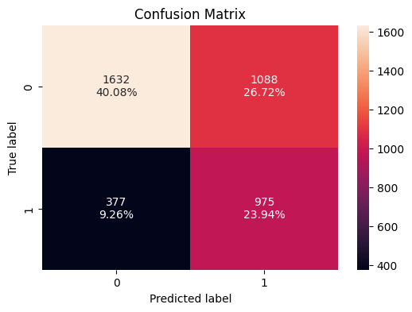

```python
# Display predicted class distribution on validation set
print("Predicted class distribution on Validation set:")
print(pd.Series(y_val_pred).value_counts())

# Display confusion matrix on validation set
print("\nConfusion Matrix on Validation set:")
confusion_matrix_sklearn(tuned_ada, X_val_df, y_val)
```

**Best practices for hyperparameter tuning in Random Forest:**

`n_estimators`:

- Start with a specific number (50 is used in general) and increase in steps: 50, 75, 100, 125
- Higher values generally improve performance but increase training time
- Use 100-150 for large datasets or when variance is high

`min_samples_leaf`:

- Try values like: 1, 2, 4, 5, 10
- Higher values reduce model complexity and help prevent overfitting
- Use 1–2 for low-bias models, higher (like 5 or 10) for more regularized models
- Works well in noisy datasets to smooth predictions

`max_features`:

- Try values: `"sqrt"` (default for classification), `"log2"`, `None`, or float values (e.g., `0.3`, `0.5`)
- `"sqrt"` balances between diversity and performance for classification tasks
- Lower values (e.g., `0.3`) increase tree diversity, reducing overfitting
- Higher values (closer to `1.0`) may capture more interactions but risk overfitting

`max_samples` (for bootstrap sampling):

- Try float values between `0.5` to `1.0` or fixed integers
- Use `0.6–0.9` to introduce randomness and reduce overfitting
- Smaller values increase diversity between trees, improving generalization

```python
model = RandomForestClassifier(random_state=42) #Defining the model.

#Parameter grid to pass through RandomizedSearch CV
param_grid = {
    'n_estimators': [50, 75, 100, 125],
    'min_samples_leaf': [1, 2, 4, 5, 10],
    'max_features': ['sqrt', 'log2', None, 0.3, 0.5],
    'max_samples': [0.5, 0.6, 0.7, 0.8, 0.9, 1.0]
}

#calling randomized search CV.
randomized_cv_rf = RandomizedSearchCV(estimator=model, param_distributions=param_grid, n_iter=50, n_jobs=-1, cv=5, scoring=f1_scorer, random_state=42)
randomized_cv_rf.fit(X_train_rus, y_train_rus)

#print results
print("Best parameters:", randomized_cv_rf.best_params_)
print("Best cross-validation score:", randomized_cv_rf.best_score_)
```

```
Best parameters: {'n_estimators': 100, 'min_samples_leaf': 10, 'max_samples': 1.0, 'max_features': 'sqrt'}
Best cross-validation score: 0.7201350339522119
```

```python
from sklearn.metrics import accuracy_score, precision_score, recall_score, f1_score, classification_report

tuned_rf = randomized_cv_rf.best_estimator_
tuned_rf.fit(X_train_rus, y_train_rus)

# Evaluate on training set (undersampled)
y_train_rus_pred = tuned_rf.predict(X_train_rus)
print("Tuned Random Forest Model Performance on Training Set (Undersampled):")
print(f"Accuracy: {accuracy_score(y_train_rus, y_train_rus_pred):.4f}")
print(f"Precision: {precision_score(y_train_rus, y_train_rus_pred, pos_label='Certified'):.4f}")
print(f"Recall: {recall_score(y_train_rus, y_train_rus_pred, pos_label='Certified'):.4f}")
print(f"F1 Score: {f1_score(y_train_rus, y_train_rus_pred, pos_label='Certified'):.4f}")
print("\nClassification Report (Training):")
print(classification_report(y_train_rus, y_train_rus_pred, target_names=['Denied', 'Certified']))

# Evaluate on validation set
# Ensure X_val_df is available and scaled appropriately if needed by the tuned model
# Based on previous steps, X_val_df is already created and scaled
y_val_pred = tuned_rf.predict(X_val_df)
print("\nTuned Random Forest Model Performance on Validation Set:")
print(f"Accuracy: {accuracy_score(y_val, y_val_pred):.4f}")
print(f"Precision: {precision_score(y_val, y_val_pred, pos_label='Certified'):.4f}")
print(f"Recall: {recall_score(y_val, y_val_pred, pos_label='Certified'):.4f}")
print(f"F1 Score (Certified): {f1_score(y_val, y_val_pred, pos_label='Certified'):.4f}")
print(f"F1 Score (Macro): {f1_score(y_val, y_val_pred, average='macro'):.4f}") # Also include macro F1 for balanced evaluation
print("\nClassification Report (Validation):")
print(classification_report(y_val, y_val_pred, target_names=['Denied', 'Certified']))
```

```
Tuned Random Forest Model Performance on Training Set (Undersampled):
Accuracy: 0.7183
Precision: 0.7077
Recall: 0.7439
F1 Score: 0.7254

Classification Report (Training):
              precision    recall  f1-score   support

      Denied       0.71      0.74      0.73      5405
   Certified       0.73      0.69      0.71      5405

    accuracy                           0.72     10810
   macro avg       0.72      0.72      0.72     10810
weighted avg       0.72      0.72      0.72     10810


Tuned Random Forest Model Performance on Validation Set:
Accuracy: 0.5228
Precision: 0.9227
Recall: 0.3118
F1 Score (Certified): 0.4661
F1 Score (Macro): 0.5174

Classification Report (Validation):
              precision    recall  f1-score   support

      Denied       0.92      0.31      0.47      2720
   Certified       0.41      0.95      0.57      1352

    accuracy                           0.52      4072
   macro avg       0.66      0.63      0.52      4072
weighted avg       0.75      0.52      0.50      4072
```

```python
#This model performed the almost perfect on precision but on f1 score it still seems to be a bit low.
```

```
Tuned Random Forest Model Performance on Validation Set:
Accuracy: 0.7168
Precision: 0.8231
Recall: 0.7338
F1 Score (Certified): 0.7759
F1 Score (Macro): 0.6957

Classification Report (Validation):
              precision    recall  f1-score   support

      Denied       0.82      0.73      0.78      2720
   Certified       0.56      0.68      0.62      1352

    accuracy                           0.72      4072
   macro avg       0.69      0.71      0.70      4072
weighted avg       0.74      0.72      0.72      4072


Confusion Matrix (Validation):
```

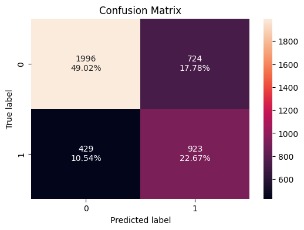

```python
from sklearn.metrics import accuracy_score, precision_score, recall_score, f1_score, classification_report, confusion_matrix

# Get the best model from RandomizedSearchCV
tuned_rf = randomized_cv_rf.best_estimator_

# Predict on the validation set
y_val_pred_rf = tuned_rf.predict(X_val_df)

print("Tuned Random Forest Model Performance on Validation Set:")
print(f"Accuracy: {accuracy_score(y_val, y_val_pred_rf):.4f}")
print(f"Precision: {precision_score(y_val, y_val_pred_rf, pos_label='Certified'):.4f}")
print(f"Recall: {recall_score(y_val, y_val_pred_rf, pos_label='Certified'):.4f}")
print(f"F1 Score (Certified): {f1_score(y_val, y_val_pred_rf, pos_label='Certified'):.4f}")
print(f"F1 Score (Macro): {f1_score(y_val, y_val_pred_rf, average='macro'):.4f}")

print("\nClassification Report (Validation):")
print(classification_report(y_val, y_val_pred_rf, target_names=['Denied', 'Certified']))

print("\nConfusion Matrix (Validation):")
confusion_matrix_sklearn(tuned_rf, X_val_df, y_val)
```

**Best practices for hyperparameter tuning in Gradient Boosting:**

`n_estimators`:

- Start with 100 (default) and increase: 100, 200, 300, 500
- Typically, higher values lead to better performance, but they also increase training time
- Use 200–500 for larger datasets or complex problems
- Monitor validation performance to avoid overfitting, as too many estimators can degrade generalization

`learning_rate`:

- Common values to try: 0.1, 0.05, 0.01, 0.005
- Use lower values (e.g., 0.01 or 0.005) if you are using many estimators (e.g., > 200)
- Higher learning rates (e.g., 0.1) can be used with fewer estimators for faster convergence
- Always balance the learning rate with `n_estimators` to prevent overfitting or underfitting

`subsample`:

- Common values: 0.7, 0.8, 0.9, 1.0
- Use a value between `0.7` and `0.9` for improved generalization by introducing randomness
- `1.0` uses the full dataset for each boosting round, potentially leading to overfitting
- Reducing `subsample` can help reduce overfitting, especially in smaller datasets

`max_features`:

- Common values: `"sqrt"`, `"log2"`, or float (e.g., `0.3`, `0.5`)
- `"sqrt"` (default) works well for classification tasks
- Lower values (e.g., `0.3`) help reduce overfitting by limiting the number of features considered at each split

```python
%%time

#Defining the model
model = GradientBoostingClassifier(random_state=42)

#Parameter grid for randomized search cv.
param_grid = {
    'n_estimators': [100, 200, 300, 500],
    'learning_rate': [0.1, 0.05, 0.01, 0.005],
    'subsample': [0.7, 0.8, 0.9, 1.0],
    'max_features': ['sqrt', 'log2', 0.3, 0.5]
}

#Calling randomized search cv.
randomized_cv_gb = RandomizedSearchCV(estimator=model, param_distributions=param_grid, n_iter=50, n_jobs=-1, cv=5, scoring=f1_scorer, random_state=42)
randomized_cv_gb.fit(X_train_rus, y_train_rus)

#Print results.
print("Best parameters:", randomized_cv_gb.best_params_)
print("Best cross-validation score:", randomized_cv_gb.best_score_)
```

```
Best parameters: {'subsample': 0.7, 'n_estimators': 200, 'max_features': 'sqrt', 'learning_rate': 0.005}
Best cross-validation score: 0.7228228806177435
CPU times: user 45.8 s, sys: 928 ms, total: 46.7 s
Wall time: 4min 32s
```

```python
#Defined model.
tuned_gbm = randomized_cv_gb.best_estimator_
tuned_gbm.fit(X_train_rus, y_train_rus) #Fit model into training set.
y_train_rus_pred = tuned_gbm.predict(X_train_rus) #Predicted training set.

#Print results for training set.
print("Tuned Gradient Boosting Model Performance on Training Set (Undersampled):")
print(f"Accuracy: {accuracy_score(y_train_rus, y_train_rus_pred):.4f}")
print(f"Precision: {precision_score(y_train_rus, y_train_rus_pred, pos_label='Certified'):.4f}")
print(f"Recall: {recall_score(y_train_rus, y_train_rus_pred, pos_label='Certified'):.4f}")
print(f"F1 Score: {f1_score(y_train_rus, y_train_rus_pred, pos_label='Certified'):.4f}")
print("\nClassification Report (Training):")
print(classification_report(y_train_rus, y_train_rus_pred, target_names=['Denied', 'Certified']))

#Print results for validation set
print("\nTuned Gradient Boosting Model Performance on Validation Set:")
y_val_pred = tuned_gbm.predict(X_val_df)
print(f"Accuracy: {accuracy_score(y_val, y_val_pred):.4f}")
print(f"Precision: {precision_score(y_val, y_val_pred, pos_label='Certified'):.4f}")
print(f"Recall: {recall_score(y_val, y_val_pred, pos_label='Certified'):.4f}")
print(f"F1 Score (Certified): {f1_score(y_val, y_val_pred, pos_label='Certified'):.4f}")
print(f"F1 Score (Macro): {f1_score(y_val, y_val_pred, average='macro'):.4f}")
print("\nClassification Report (Validation):")
print(classification_report(y_val, y_val_pred, target_names=['Denied', 'Certified']))
```

```
Tuned Gradient Boosting Model Performance on Training Set (Undersampled):
Accuracy: 0.7006
Precision: 0.6729
Recall: 0.7806
F1 Score: 0.7227

Classification Report (Training):
              precision    recall  f1-score   support

      Denied       0.67      0.78      0.72      5405
   Certified       0.74      0.62      0.67      5405

    accuracy                           0.70     10810
   macro avg       0.71      0.70      0.70     10810
weighted avg       0.71      0.70      0.70     10810


Tuned Gradient Boosting Model Performance on Validation Set:
Accuracy: 0.4472
Precision: 0.9400
Recall: 0.1842
F1 Score (Certified): 0.3080
F1 Score (Macro): 0.4239

Classification Report (Validation):
              precision    recall  f1-score   support

      Denied       0.94      0.18      0.31      2720
   Certified       0.37      0.98      0.54      1352

    accuracy                           0.45      4072
   macro avg       0.66      0.58      0.42      4072
weighted avg       0.75      0.45      0.38      4072
```

```python
#Graident boost did not perform as well as random forest when you compare f1 scores. But the precision on gradient boosting was very high.
```

**Best practices for hyperparameter tuning in XGBoost:**

`n_estimators`:

- Start with 50 and increase in steps: 50,75,100,125.
- Use more estimators (e.g., 150-250) when using lower learning rates
- Monitor validation performance
- High values improve learning but increase training time

`subsample`:

- Common values: 0.5, 0.7, 0.8, 1.0
- Use `0.7–0.9` to introduce randomness and reduce overfitting
- `1.0` uses the full dataset in each boosting round; may overfit on small datasets
- Values < 0.5 are rarely useful unless dataset is very large

`gamma`:

- Try values: 0 (default), 1, 3, 5, 8
- Controls minimum loss reduction needed for a split
- Higher values make the algorithm more conservative (i.e., fewer splits)
- Use values > 0 to regularize and reduce overfitting, especially on noisy data

`colsample_bytree`:

- Try values: 0.3, 0.5, 0.7, 1.0
- Fraction of features sampled per tree
- Lower values (e.g., 0.3 or 0.5) increase randomness and improve generalization
- Use `1.0` when you want all features considered for every tree

`colsample_bylevel`:

- Try values: 0.3, 0.5, 0.7, 1.0
- Fraction of features sampled at each tree level (i.e., per split depth)
- Lower values help in regularization and reducing overfitting
- Often used in combination with `colsample_bytree` for fine control over feature sampling

```python
#I opted out of performing test for XGBoost due to how long it takes to compute.
```

## Model Performance Summary and Final Model Selection

```python
#Defining model.
def evaluate_model(model_name, model, X_train, y_train, X_val, y_val):
  y_train_pred = model.predict(X_train)
  y_val_pred = model.predict(X_val)
  return {
      'Model': model_name,
      'Accuracy': accuracy_score(y_val, y_val_pred),
      'Precision': precision_score(y_val, y_val_pred, pos_label='Certified'),
      'Recall': recall_score(y_val, y_val_pred, pos_label='Certified'),
      'F1 Score (Certified)': f1_score(y_val, y_val_pred, pos_label='Certified'),
      'F1 Score (Macro)': f1_score(y_val, y_val_pred, average='macro'),

  }


#Show results for validation models.
results = []

results.append(evaluate_model('Tuned Adaboost', tuned_ada, X_train_rus, y_train_rus, X_val_df, y_val))
results.append(evaluate_model('Tuned Random Forest', tuned_rf, X_train_rus, y_train_rus, X_val_df, y_val))
results.append(evaluate_model('Tuned Gradient Boosting', tuned_gbm, X_train_rus, y_train_rus, X_val_df, y_val))

results_df = pd.DataFrame(results, columns=['Model', 'Accuracy', 'Precision', 'Recall', 'F1 Score (Certified)', 'F1 Score (Macro)'])
results_df = results_df.sort_values(by='F1 Score (Certified)', ascending=False)
print(results_df)
```

```
                     Model  Accuracy  Precision    Recall  \
0           Tuned Adaboost  0.640226   0.812344  0.600000
1      Tuned Random Forest  0.522839   0.922742  0.311765
2  Tuned Gradient Boosting  0.447200   0.939962  0.184191

   F1 Score (Certified)  F1 Score (Macro)
0              0.690209          0.630610
1              0.466062          0.517382
2              0.308023          0.423895
```

```python
#When I ran the hyperparameters for Adaboost above it didnt give me back any test results on the valdation data. But now it seems to have worked out the best for the f1 score. Although it had the worst precision out of the other 2 models.
```

```python
test = model_performance_classification_sklearn(tuned_ada, X_test, y_test)
test
```

[output not shown]

```python
#I am not sure why I am not able to test the data to find out my final model prediction. I think i may have done something wrong in the model_selection for sklearn where I had to determine how may attributes it can hold.
```

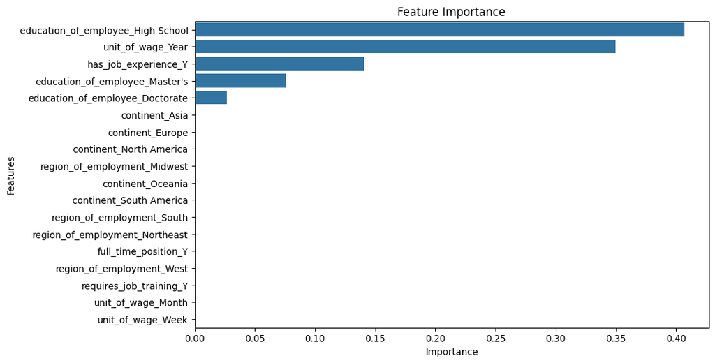

```python
feature_names = X_train_rus.columns.tolist()
importances = tuned_ada.feature_importances_
feature_importances = pd.Series(importances, index=feature_names)
feature_importances = feature_importances.sort_values(ascending=False)

plt.figure(figsize=(10, 6))
sns.barplot(x=feature_importances, y=feature_importances.index)
plt.xlabel('Importance')
plt.ylabel('Features')
plt.title('Feature Importance')
plt.show()
```

## Actionable Insights and Recommendations

Power Ahead

```python
#Adaboost seemed to be the best determinant on whether or not someone should get certified or denied.
#Ironically the most valuable feature on determining if they would get certified was their education level. Although appliacants with at least a high school educaiton seemed to hold the most weight.
#Unit of wage came in second. This was based on how much someone made annually.
#Job experience also played a crucial role in determining if some got certified or not.
```

[output not shown]

[output cut: 136 more lines]

[output not shown]

[output not shown]

[output cut: 136 more lines]

[output not shown]